# Regression iib

Anna Heltz

2022-12-05

```r
DF <- readr::read_csv("fall2022_finalproject.csv", col_names = TRUE)
DF %>% glimpse()
```

```
## Rows: 1,252
## Columns: 11
## $ x1     <dbl> 0.025878, 0.030768, 0.019325, 0.306212, 0.031296, 0.031073, 0.0…
## $ x2     <dbl> 0.255934, 0.261575, 0.020877, 0.033379, 0.259342, 0.027119, 0.0…
## $ x3     <dbl> 0.492830, 0.498460, 0.258360, 0.255385, 0.264387, 0.260915, 0.0…
## $ x4     <dbl> 0.012770, 0.055779, 0.012424, 0.056190, 0.056594, 0.055192, 0.0…
## $ v1     <dbl> 0.275651, 0.343204, 4.998508, 5.090153, 5.031107, 9.977407, 0.2…
## $ v2     <dbl> 0.033657, 0.027082, 0.030259, 0.052342, 0.517705, 0.532436, 1.0…
## $ v3     <dbl> 1.166214, 1.260579, 1.298285, 1.322005, 1.368195, 1.298797, 1.1…
## $ v4     <dbl> 0.408402, 0.664248, 0.412870, 0.652111, 0.533701, 0.857509, 0.6…
## $ v5     <dbl> 0.525226, 2.866343, 0.409007, 0.861594, 6.451933, 0.958574, 0.2…
## $ m      <chr> "A", "A", "A", "A", "A", "A", "A", "A", "A", "A", "A", "A", "A"…
## $ output <dbl> 0.786, 0.730, 0.996, 0.326, 0.735, 0.954, 0.969, 0.986, 0.874, …
```

| creating the DF in this file |
| --- |

```r
newDF <- DF %>%
  mutate(x5 = 1 - (x1 + x2 + x3 + x4),
         w = x2 / (x3 + x4),
         z = (x1 + x2) / (x5 + x4),
         t = v1 * v2,
         outcome = ifelse(output < 0.33, 'event', 'non_event'),
         outcome = factor(outcome, levels = c("event", "non_event")),
          y = boot::logit(output))
```

```r
newDF %>% glimpse()
```

```
## Rows: 1,252
## Columns: 17
## $ x1      <dbl> 0.025878, 0.030768, 0.019325, 0.306212, 0.031296, 0.031073, 0.…
## $ x2      <dbl> 0.255934, 0.261575, 0.020877, 0.033379, 0.259342, 0.027119, 0.…
## $ x3      <dbl> 0.492830, 0.498460, 0.258360, 0.255385, 0.264387, 0.260915, 0.…
## $ x4      <dbl> 0.012770, 0.055779, 0.012424, 0.056190, 0.056594, 0.055192, 0.…
## $ v1      <dbl> 0.275651, 0.343204, 4.998508, 5.090153, 5.031107, 9.977407, 0.…
## $ v2      <dbl> 0.033657, 0.027082, 0.030259, 0.052342, 0.517705, 0.532436, 1.…
## $ v3      <dbl> 1.166214, 1.260579, 1.298285, 1.322005, 1.368195, 1.298797, 1.…
## $ v4      <dbl> 0.408402, 0.664248, 0.412870, 0.652111, 0.533701, 0.857509, 0.…
## $ v5      <dbl> 0.525226, 2.866343, 0.409007, 0.861594, 6.451933, 0.958574, 0.…
## $ m       <chr> "A", "A", "A", "A", "A", "A", "A", "A", "A", "A", "A", "A", "A…
## $ output  <dbl> 0.786, 0.730, 0.996, 0.326, 0.735, 0.954, 0.969, 0.986, 0.874,…
## $ x5      <dbl> 0.212588, 0.153418, 0.689014, 0.348834, 0.388381, 0.625701, 0.…
## $ w       <dbl> 0.50619858, 0.47195344, 0.07709835, 0.10712990, 0.80796683, 0.…
## $ z       <dbl> 1.25050808, 1.39745312, 0.05731369, 0.83844661, 0.65315580, 0.…
## $ t       <dbl> 0.009277586, 0.009294651, 0.151249854, 0.266428788, 2.60462924…
## $ outcome <fct> non_event, non_event, non_event, event, non_event, non_event, …
## $ y       <dbl> 1.3009808, 0.9946226, 5.5174529, -0.7263327, 1.0201407, 3.0320…
```

*Fitting Bayesian Models* I will be fitting the top 2 models from my linear models. This is because I would like to see how my top 2 models compare. ————————————————————————————————————————–

```r
linearBasisMod3 <-  lm(y ~ splines::ns(x1, 5) * (I(x2^2)) * (I(x3^2))+ t + z + w , data = newDF)
linearBasisMod3
```

```
##
## Call:
## lm(formula = y ~ splines::ns(x1, 5) * (I(x2^2)) * (I(x3^2)) +
##     t + z + w, data = newDF)
##
## Coefficients:
##                         (Intercept)                  splines::ns(x1, 5)1
##                              4.3626                              -5.3100
##                 splines::ns(x1, 5)2                  splines::ns(x1, 5)3
##                             -6.5860                              -4.2034
##                 splines::ns(x1, 5)4                  splines::ns(x1, 5)5
##                            -16.1987                              -6.3143
##                             I(x2^2)                              I(x3^2)
##                            -49.1254                               2.6721
##                                   t                                    z
##                             -0.0311                               2.9745
##                                   w          splines::ns(x1, 5)1:I(x2^2)
##                              0.6388                              -6.3650
##         splines::ns(x1, 5)2:I(x2^2)          splines::ns(x1, 5)3:I(x2^2)
##                             22.4545                             -66.3954
##         splines::ns(x1, 5)4:I(x2^2)          splines::ns(x1, 5)5:I(x2^2)
##                            112.4036                              79.4159
##         splines::ns(x1, 5)1:I(x3^2)          splines::ns(x1, 5)2:I(x3^2)
##                            -23.4733                             -28.9765
##         splines::ns(x1, 5)3:I(x3^2)          splines::ns(x1, 5)4:I(x3^2)
##                            -48.4891                             -33.0006
##         splines::ns(x1, 5)5:I(x3^2)                      I(x2^2):I(x3^2)
##                            -18.7997                             -70.8179
## splines::ns(x1, 5)1:I(x2^2):I(x3^2)  splines::ns(x1, 5)2:I(x2^2):I(x3^2)
##                           -105.9928                            -899.0537
## splines::ns(x1, 5)3:I(x2^2):I(x3^2)  splines::ns(x1, 5)4:I(x2^2):I(x3^2)
##                            889.7722                           -3190.2956
## splines::ns(x1, 5)5:I(x2^2):I(x3^2)
##                          -4976.1155
```

```r
linearBasisMod4 <-  lm(y ~ splines::ns(x1, 5) * splines::ns(z, 5)+ m , data = newDF)
linearBasisMod4
```

```
##
## Call:
## lm(formula = y ~ splines::ns(x1, 5) * splines::ns(z, 5) + m,
##     data = newDF)
##
## Coefficients:
##                            (Intercept)                     splines::ns(x1, 5)1
##                                6.18080                                -1.49357
##                    splines::ns(x1, 5)2                     splines::ns(x1, 5)3
##                              -11.15559                                19.37763
##                    splines::ns(x1, 5)4                     splines::ns(x1, 5)5
##                              -95.34500                              -157.04449
##                     splines::ns(z, 5)1                      splines::ns(z, 5)2
##                               -2.65110                                -9.21988
##                     splines::ns(z, 5)3                      splines::ns(z, 5)4
##                                4.36704                                -5.29196
##                     splines::ns(z, 5)5                                      mB
##                               -2.37910                                -0.21639
##                                     mC                                      mD
##                                0.01371                                -0.26356
##                                     mE  splines::ns(x1, 5)1:splines::ns(z, 5)1
##                                0.11223                                -2.30592
## splines::ns(x1, 5)2:splines::ns(z, 5)1  splines::ns(x1, 5)3:splines::ns(z, 5)1
##                                5.93294                               -20.79308
## splines::ns(x1, 5)4:splines::ns(z, 5)1  splines::ns(x1, 5)5:splines::ns(z, 5)1
##                               84.85925                               156.47277
## splines::ns(x1, 5)1:splines::ns(z, 5)2  splines::ns(x1, 5)2:splines::ns(z, 5)2
##                               -0.41571                                14.52034
## splines::ns(x1, 5)3:splines::ns(z, 5)2  splines::ns(x1, 5)4:splines::ns(z, 5)2
##                              -19.57609                               101.32013
## splines::ns(x1, 5)5:splines::ns(z, 5)2  splines::ns(x1, 5)1:splines::ns(z, 5)3
##                              158.23064                                -5.70906
## splines::ns(x1, 5)2:splines::ns(z, 5)3  splines::ns(x1, 5)3:splines::ns(z, 5)3
##                               -0.72996                               -12.81044
## splines::ns(x1, 5)4:splines::ns(z, 5)3  splines::ns(x1, 5)5:splines::ns(z, 5)3
##                               49.09737                               108.63163
## splines::ns(x1, 5)1:splines::ns(z, 5)4  splines::ns(x1, 5)2:splines::ns(z, 5)4
##                               -2.95816                                17.55453
## splines::ns(x1, 5)3:splines::ns(z, 5)4  splines::ns(x1, 5)4:splines::ns(z, 5)4
##                              -31.37555                               174.74045
## splines::ns(x1, 5)5:splines::ns(z, 5)4  splines::ns(x1, 5)1:splines::ns(z, 5)5
##                              303.00777                                 4.24991
## splines::ns(x1, 5)2:splines::ns(z, 5)5  splines::ns(x1, 5)3:splines::ns(z, 5)5
##                                9.17694                                -3.95764
## splines::ns(x1, 5)4:splines::ns(z, 5)5  splines::ns(x1, 5)5:splines::ns(z, 5)5
##                               48.99834                                73.73823
```

```r
#design matrices for the top 2 models
mod_3DM <- model.matrix(y ~ splines::ns(x1, 5) * (I(x2^2)) * (I(x3^2))+ t + z + w, data = newDF)
mod_4DM <- model.matrix(y ~ splines::ns(x1, 5) * splines::ns(z, 5)+ m , data = newDF)
```

```r
info_mod3 <- list(
  yobs = newDF$y,### the measurements
  design_matrix = mod_3DM,
  mu_beta = 0,
  tau_beta = 3,
  sigma_rate = 1
)
info_mod4 <- list(
  yobs = newDF$y,### the measurements
  design_matrix = mod_4DM,
  mu_beta = 0,
  tau_beta = 3,
  sigma_rate = 1
)
```

```r
lm_logpost <- function(unknowns, my_info)
{
  # specify the number of unknown beta parameters
  length_beta <- ncol(my_info$design_matrix)

  # extract the beta parameters from the `unknowns` vector
  beta_v <- unknowns[1:length_beta]

  # extract the unbounded noise parameter, varphi
  lik_varphi <- unknowns[length_beta + 1]

  # back-transform from varphi to sigma
  lik_sigma <- exp(lik_varphi)

  # extract design matrix
  X <- my_info$design_matrix

  # calculate the linear predictor
  mu <- as.vector(X %*% as.matrix(beta_v))

  # evaluate the log-likelihood
  log_lik <- sum(dnorm(x = my_info$yobs,
                       mean = mu,
                       sd = lik_sigma,
                       log = TRUE))

  # evaluate the log-prior
  log_prior_beta <- sum(dnorm(x = beta_v,
                              mean = my_info$mu_beta,
                              sd = my_info$tau_beta,
                              log = TRUE))

  log_prior_sigma <- dexp(x = lik_sigma,
                          rate = my_info$sigma_rate,
                          log = TRUE)

  # add the mean trend prior and noise prior together
  log_prior <- log_prior_beta + log_prior_sigma

  # account for the transformation
  log_derive_adjust <- lik_varphi

  # sum together
  log_lik + log_prior + log_derive_adjust
}
```

```r
my_laplace <- function(start_guess, logpost_func, ...)
{
  # code adapted from the `LearnBayes`` function `laplace()`
  fit <- optim(start_guess,
               logpost_func,
               gr = NULL,
               ...,
               method = "BFGS",
               hessian = TRUE,
               control = list(fnscale = -1, maxit = 1001))

  mode <- fit$par
  post_var_matrix <- -solve(fit$hessian)
  p <- length(mode)
  int <- p/2 * log(2 * pi) + 0.5 * log(det(post_var_matrix)) + logpost_func(mode, ...)
  # package all of the results into a list
  list(mode = mode,
       var_matrix = post_var_matrix,
       log_evidence = int,
       converge = ifelse(fit$convergence == 0,
                         "YES",
                         "NO"),
       iter_counts = as.numeric(fit$counts[1]))
}
```

Bayesian Linear Model for our second best model; Model 3

```r
laplace_mod3 <- my_laplace(rep(0, ncol(mod_3DM)+1), lm_logpost, info_mod3)
cat("The posterior mode for model 3:\n",laplace_mod3$mode)
```

```
## The posterior mode for model 3:
##  4.306277 -5.811676 -6.408354 -3.566662 -12.24457 -3.381219 -28.06281 -5.418672 -0.0253984 1.676139 0.7843949 -6.077795 -3.41072 8.366705 -3.631642 4.51549 -8.03751 -13.23081 -4.625153 -2.730073 4.265644 -6.260357 -0.8272931 -0.5521131 0.9880353 -1.441794 0.8791756 0.2270635
```

```r
cat("\nThe posterior standard deviation  for model 3:\n",laplace_mod3$var_matrix %>% diag() %>% sqrt())
```

```
##
## The posterior standard deviation  for model 3:
##  0.2317913 0.296187 0.2865851 0.2960164 0.5621723 0.2900721 1.953882 1.087009 0.01707223 0.05677974 0.2119902 2.618331 2.495758 2.830846 2.739505 2.902532 2.016239 1.839996 2.361214 2.521486 2.684083 2.94825 2.994809 2.997197 2.998155 2.993726 2.997966 0.02098974
```

Bayesian Linear Model for our best model; Model 4

```r
laplace_mod4 <- my_laplace(rep(0, ncol(mod_4DM)+1), lm_logpost, info_mod4)
cat("The posterior mode for model 4:\n",laplace_mod4$mode)
```

```
## The posterior mode for model 4:
##  5.219944 -3.551377 -4.221161 2.634125 -7.631931 4.266103 -2.827526 -5.137758 1.369676 -1.360756 1.865436 -0.2024455 0.01370644 -0.2555994 0.1000335 0.09435743 0.7108648 -4.19156 1.258679 -3.633289 -0.3653728 3.966944 -3.39675 5.217506 -4.010334 -1.98558 -0.9790374 -0.9087979 -0.09425398 1.614668…
```

```r
cat("\nThe posterior standard deviation  for model 4:\n",laplace_mod4$var_matrix %>% diag() %>% sqrt())
```

```
##
## The posterior standard deviation  for model 4:
##  0.2229863 0.6923202 0.9192725 1.073585 0.8875965 1.097456 0.4972595 0.696574 0.7204403 0.7212376 0.8237989 0.1001275 0.09888653 0.09903686 0.1003504 0.8585884 1.047542 1.29715 1.55246 1.384738 1.127408 1.224317 1.311292 1.828082 1.301435 1.09668 1.008401 1.198788 1.886686 1.442913 1.665241 2.003…
```

| These Bayesian models give us UNCERTAINTY on the residual error. |
| --- |

*How will we pick our best model?* We cannot compare the models with the same performance metrics as we did with the Non-Bayesian Linear Models. This is because uncertainty on the $\beta$ parameters induce uncertainty on the mean trend, $\mu$. Uncertainty on the mean trend induces uncertainty in the performance metrics! The uncertainty however, when assessed ONLY on the training set will not prevent overfitting! Therefore, instead we will compare models based on their Evidence values with Bayes Factors for Bayesian Models.

```r
cat("Bayes factor to compare our 2 Bayesian MOdels is: ", exp( laplace_mod3$log_evidence - laplace_mod4$log_evidence ))
```

```
## Bayes factor to compare our 2 Bayesian MOdels is:  4.214138e-94
```

As we can see here, since the bayes factor is much less than one, we can tell that model 4 is considered to be better than model 3.

*Now that we have our best model, which is model 4, lets visualize the regression coefficient posterior summary statistics*

```r
viz_post_coefs <- function(post_means, post_sds, xnames)
{
  tibble::tibble(
    mu = post_means,
    sd = post_sds,
    x = xnames
  ) %>%
    mutate(x = factor(x, levels = xnames)) %>%
    ggplot(mapping = aes(x = x)) +
    geom_hline(yintercept = 0, color = 'grey', linetype = 'dashed') +
    geom_point(mapping = aes(y = mu)) +
    geom_linerange(mapping = aes(ymin = mu - 2 * sd,
                                 ymax = mu + 2 * sd,
                                 group = x)) +
    labs(x = 'feature', y = 'coefficient value') +
    coord_flip() +
    theme_bw()
}
```

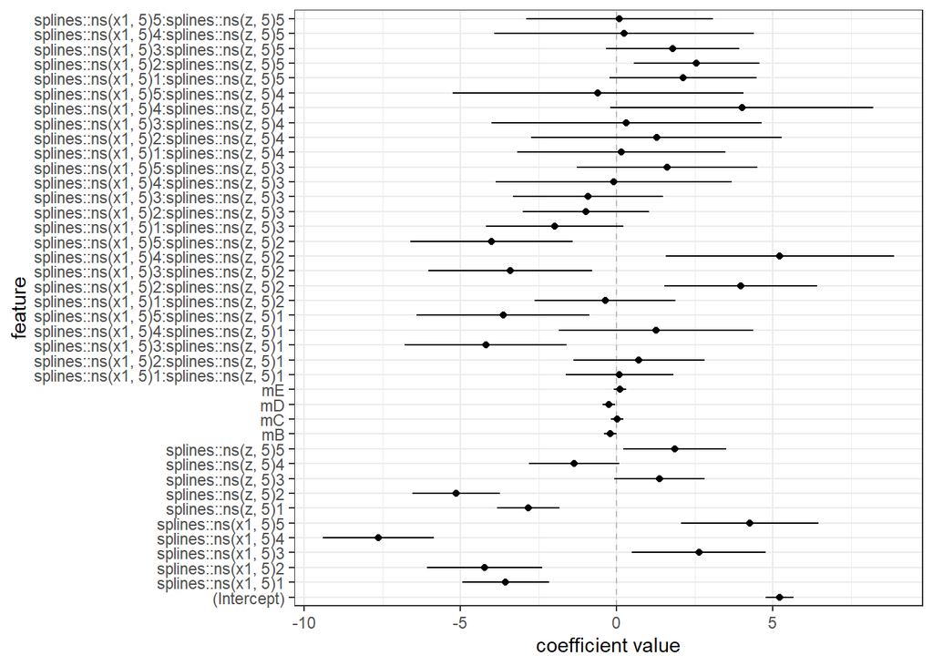

```r
viz_post_coefs(laplace_mod4$mode[1:ncol(mod_4DM)],
               sqrt(diag(laplace_mod4$var_matrix)[1:ncol(mod_4DM)]),
               colnames(mod_4DM))
```

As you can see in the coefficient posterior summary statistics for our best model, model 4, we can see that most of the coefficients are very uncertain.$\sigma$ acts as a scaling term on the posterior uncertainty. To calculate the covariance matrix for the regression coefficients, we will assume that $\sigma$=1 so we can examine the scaled uncertainty.

```r
covmat_quad_mod4 <- 1^2 * solve( t(mod_4DM) %*% mod_4DM )
covmat_quad_mod4 %>% diag() %>% sqrt()
```

```
##                            (Intercept)                    splines::ns(x1, 5)1
##                             0.25008104                             0.95430129
##                    splines::ns(x1, 5)2                    splines::ns(x1, 5)3
##                             1.87481268                             8.04650718
##                    splines::ns(x1, 5)4                    splines::ns(x1, 5)5
##                            34.70577276                            63.50306720
##                     splines::ns(z, 5)1                     splines::ns(z, 5)2
##                             0.56586003                             1.00222537
##                     splines::ns(z, 5)3                     splines::ns(z, 5)4
##                             1.15348957                             0.99728218
##                     splines::ns(z, 5)5                                     mB
##                             1.43209082                             0.09281596
##                                     mC                                     mD
##                             0.09169308                             0.09180468
##                                     mE splines::ns(x1, 5)1:splines::ns(z, 5)1
##                             0.09312194                             0.99586687
## splines::ns(x1, 5)2:splines::ns(z, 5)1 splines::ns(x1, 5)3:splines::ns(z, 5)1
##                             1.84203403                             7.79522045
## splines::ns(x1, 5)4:splines::ns(z, 5)1 splines::ns(x1, 5)5:splines::ns(z, 5)1
##                            34.56538326                            63.27450573
## splines::ns(x1, 5)1:splines::ns(z, 5)2 splines::ns(x1, 5)2:splines::ns(z, 5)2
##                             1.45497686                             2.23383435
## splines::ns(x1, 5)3:splines::ns(z, 5)2 splines::ns(x1, 5)4:splines::ns(z, 5)2
##                             8.21169262                            34.86765228
## splines::ns(x1, 5)5:splines::ns(z, 5)2 splines::ns(x1, 5)1:splines::ns(z, 5)3
##                            63.60584546                             1.32629568
## splines::ns(x1, 5)2:splines::ns(z, 5)3 splines::ns(x1, 5)3:splines::ns(z, 5)3
##                             1.68206475                             5.20974468
## splines::ns(x1, 5)4:splines::ns(z, 5)3 splines::ns(x1, 5)5:splines::ns(z, 5)3
##                            23.54811523                            42.84299232
## splines::ns(x1, 5)1:splines::ns(z, 5)4 splines::ns(x1, 5)2:splines::ns(z, 5)4
##                             2.29666570                             4.07800648
## splines::ns(x1, 5)3:splines::ns(z, 5)4 splines::ns(x1, 5)4:splines::ns(z, 5)4
##                            15.76075281                            64.80164585
## splines::ns(x1, 5)5:splines::ns(z, 5)4 splines::ns(x1, 5)1:splines::ns(z, 5)5
##                           118.31123814                             1.44918347
## splines::ns(x1, 5)2:splines::ns(z, 5)5 splines::ns(x1, 5)3:splines::ns(z, 5)5
##                             1.70407154                             3.50559401
## splines::ns(x1, 5)4:splines::ns(z, 5)5 splines::ns(x1, 5)5:splines::ns(z, 5)5
##                            16.42485502                            29.43459674
```

These are the posterior standard deviation for each feature in our model.

```r
y_col <- newDF %>% pull(y) %>% as.matrix()
head(y_col)
```

```
##            [,1]
## [1,]  1.3009808
## [2,]  0.9946226
## [3,]  5.5174529
## [4,] -0.7263327
## [5,]  1.0201407
## [6,]  3.0320223
```

```r
postmeans_quad_mod4 <- solve( t(mod_4DM) %*% mod_4DM ,
                                       t(mod_4DM) %*% y_col)
postmeans_quad_mod4
```

```
##                                                 [,1]
## (Intercept)                               6.18080433
## splines::ns(x1, 5)1                      -1.49357314
## splines::ns(x1, 5)2                     -11.15558958
## splines::ns(x1, 5)3                      19.37762510
## splines::ns(x1, 5)4                     -95.34500225
## splines::ns(x1, 5)5                    -157.04448940
## splines::ns(z, 5)1                       -2.65110294
## splines::ns(z, 5)2                       -9.21988428
## splines::ns(z, 5)3                        4.36703894
## splines::ns(z, 5)4                       -5.29195868
## splines::ns(z, 5)5                       -2.37910373
## mB                                       -0.21638787
## mC                                        0.01370947
## mD                                       -0.26355967
## mE                                        0.11222975
## splines::ns(x1, 5)1:splines::ns(z, 5)1   -2.30592144
## splines::ns(x1, 5)2:splines::ns(z, 5)1    5.93294400
## splines::ns(x1, 5)3:splines::ns(z, 5)1  -20.79308050
## splines::ns(x1, 5)4:splines::ns(z, 5)1   84.85925260
## splines::ns(x1, 5)5:splines::ns(z, 5)1  156.47277008
## splines::ns(x1, 5)1:splines::ns(z, 5)2   -0.41570835
## splines::ns(x1, 5)2:splines::ns(z, 5)2   14.52034405
## splines::ns(x1, 5)3:splines::ns(z, 5)2  -19.57609397
## splines::ns(x1, 5)4:splines::ns(z, 5)2  101.32013378
## splines::ns(x1, 5)5:splines::ns(z, 5)2  158.23064493
## splines::ns(x1, 5)1:splines::ns(z, 5)3   -5.70905694
## splines::ns(x1, 5)2:splines::ns(z, 5)3   -0.72995748
## splines::ns(x1, 5)3:splines::ns(z, 5)3  -12.81043641
## splines::ns(x1, 5)4:splines::ns(z, 5)3   49.09737178
## splines::ns(x1, 5)5:splines::ns(z, 5)3  108.63163187
## splines::ns(x1, 5)1:splines::ns(z, 5)4   -2.95815879
## splines::ns(x1, 5)2:splines::ns(z, 5)4   17.55452741
## splines::ns(x1, 5)3:splines::ns(z, 5)4  -31.37555325
## splines::ns(x1, 5)4:splines::ns(z, 5)4  174.74045248
## splines::ns(x1, 5)5:splines::ns(z, 5)4  303.00777460
## splines::ns(x1, 5)1:splines::ns(z, 5)5    4.24990784
## splines::ns(x1, 5)2:splines::ns(z, 5)5    9.17693930
## splines::ns(x1, 5)3:splines::ns(z, 5)5   -3.95763525
## splines::ns(x1, 5)4:splines::ns(z, 5)5   48.99833656
## splines::ns(x1, 5)5:splines::ns(z, 5)5   73.73823145
```

Thus, the posterior means would not change because $\sigma$ is not in the formula! I believe we are still quite uncertain about $\sigma$. Since we are uncertain about $\sigma$, I believe the MLE on $\sigma$ is uncertain, since $\sigma$ acts as a scaling term on the posterior uncertainty.